# Report of Covid-19 Pandemic in Burma

Sujani Priyangika

10/7/2022

## **1) Background**

### **1.1 Introduction of the country of Burma**

Myanmar, also called Burma, country, located in the western portion of mainland Southeast Asia. In 1989 the country’s official English name, which it had held since 1885, was changed from the Union of Burma to the Union of Myanmar; in the Burmese language the country has been known as Myanma (or, more precisely, Mranma Prañ) since the 13th century. The English name of the city that served as the country’s capital from 1948 to 2006, Rangoon, also was dropped in 1989 in favour of the common Burmese name, Yangon.

In 2005 the government began to shift its administrative canter, first to the city of Pyinmana (some 200 miles [320 km] north of Yangon) and then to Nay Pyi Taw (Naypyidaw), a newly constructed city near Pyinmana. Nay Pyi Taw was proclaimed the capital of Myanmar in 2006.

### **1.2 Location of Burma**

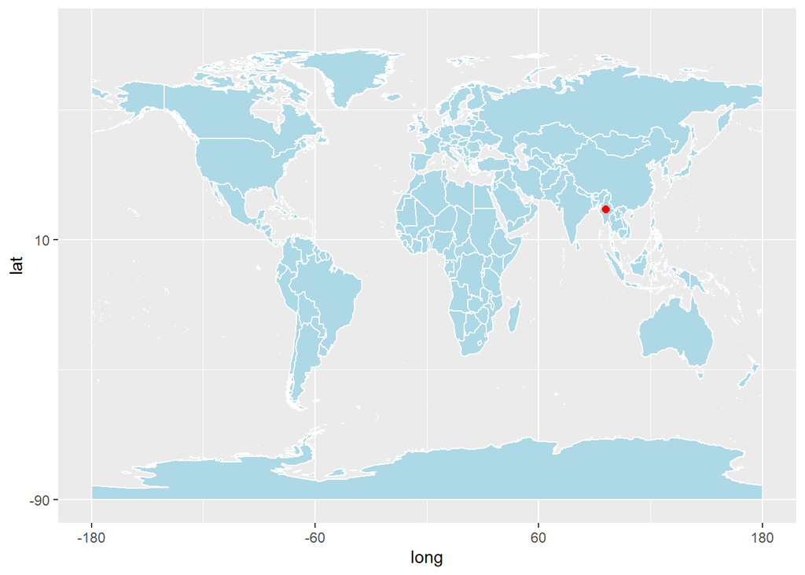

### **1.3 Geographical location of Burma**

Myanmar lies along the Indian and Eurasian Plates, to the southeast of the Tibetan Plateau. To its west is the Bay of Bengal and to its south is the Andaman Sea. The country is nestled between several mountain ranges with the Arakan Mountains on the west and the Shan Plateau dominating the east. The central valley follows the Irrawaddy River, the most economically important river to the country with 39.5 million people, including the largest city Yangon, living within its basin. The country is home to many diverse ethnic groups, with 135 officially recognized groups. It is strategically located near major Indian Ocean shipping lanes and was historically home to overland trade routes into China from the Bay of Bengal. The neighboring countries are China, India, Bangladesh, Thailand and Laos.

### **1.4 Climate Condition of Burma**

The climate of Myanmar varies depending on location and in the highlands, on elevation. The climate is subtropical/tropical and has three seasons, a "cool winter from November to February, a hot summer season in March and April and a rainy season from May to October, dominated by the southwest monsoon. A large portion of the country lies between the Tropic of Cancer and the Equator and the entirety of the country lies in the monsoon region of Asia, with its coastal regions receiving over 5,000 mm (196.9 in) of rain annually. Annual rainfall in the delta region is approximately 2,500 mm (98.4 in), while average annual rainfall in the central dry zone is less than 1,000 mm (39.4 in). The higher elevations of the highlands are predisposed to heavy snowfall, especially in the North. The Northern regions of Myanmar are the coolest, with average temperatures of 21 °C (70 °F). Coastal and delta regions have an average maximum temperature of 32 °C (89.6 °F).

### **1.5 Lockdown status of Burma**

The COVID-19 pandemic in Myanmar is part of the worldwide pandemic of coronavirus disease 2019 (COVID-19) caused by severe acute respiratory syndrome coronavirus 2 (SARS-CoV-2). The virus was confirmed to have reached Myanmar on 23 March 2020. On 31 March 2020, the Committee for Coronavirus Disease 19 (COVID-19), headed by First Vice President Myint Swe and made up of members from the various union ministries, was formed by President Win Myint to combat the spread of COVID-19 in the country.

Although the government rapidly implemented containment measures and public health responses, the country had experienced one of the most severe COVID-19 outbreaks in Southeast Asia by late 2020. The UN raised concerns about Myanmar’s vulnerability to the pandemic due to its weak healthcare infrastructure following poor investment over six decades of military rule, as well as ongoing internal conflict.

The pandemic has greatly disrupted the country’s economy and Myanmar’s GDP shrank by 5% in 2020. The 2021 coup d’état and subsequent protests and civil disobedience movement, some of which were led by healthcare workers, caused severe disruptions to the country’s public health response and deepened its recession. The country’s COVID-19 testing system and vaccination deployment are thought to have collapsed in February 2021.

### **1.6 Burma’s Policy Response to COVID-19**

#### **Number of cases**

Myanmar reported its first two cases of COVID-19 on March 23, 2020. By early August, it had recorded a total of only 360 confirmed cases and six deaths. However, the number of locally transmitted cases increased significantly from 5 per day in mid-August to 1,137 per day in mid-October. As of October 21, there were 39,696 confirmed cases and 972 deaths. By that date, Myanmar had tested 506,842 people (about 0.9% of its population) with a positive test rate of 15.1%, suggesting that confirmed cases represent only a small proportion of the true number of infected people.

#### **Health system response to COVID-19**

The country increased the number of COVID-19 testing laboratories from one in March to seven by August and more recently expanded its testing capacity to 27 district level hospitals nationwide. These laboratories can conduct over 8,000 tests per day. Myanmar has set up community quarantine sites, contact tracing procedures, COVID-19 screening and treatment guidelines for government hospitals, and fever clinics to check people for symptoms of COVID-19. In March, the country had only 0.71 intensive care unit beds and 0.46 ventilators per 100,000 people. Since then, Myanmar has taken efforts to increase surge capacity and hospital preparedness.

#### **Measures to control transmission**

Since March, the country has closed all in-bound commercial flights, sealed all land borders, enforced strict quarantine regulations, implemented partial lockdowns, banned mass gatherings, closed schools, recreational areas, and tourist places, and mandated the use of face masks. Some of these public health measures were eased before the outbreak in mid-August; however, they were reinforced and are currently in place.

#### **Barriers to epidemic control**

Myanmar’s inadequate health emergency preparedness, limited testing sites, and dependence on other countries for testing kits are some of the critical barriers to containing the pandemic. These barriers are compounded by congestion and poor living conditions in the country’s many internally displaced persons (IDPs) camps (which are risk factors for transmission), and by the ongoing conflict with Ethnic Armed Organizations (which is disrupting transport routes and supply chains for key health care commodities).

## **2) Exploratory Data Analysis**

### Qualitative data

- date - The date of the summary,
- province - The province or state, when applicable,
- country - The country or region name,
- type - the type of case (i.e., confirmed, death)

### Quantitative data

- lat - Latitude point,
- long - Longitude point,
- cases - the number of daily cases (corresponding to the case type)

```
      date              province           country               lat
 Min.   :2020-01-22   Length:2649        Length:2649        Min.   :21.92
 1st Qu.:2020-08-29   Class :character   Class :character   1st Qu.:21.92
 Median :2021-04-08   Mode  :character   Mode  :character   Median :21.92
 Mean   :2021-04-07                                         Mean   :21.92
 3rd Qu.:2021-11-15                                         3rd Qu.:21.92
 Max.   :2022-06-23                                         Max.   :21.92
      long           type               cases             uid
 Min.   :95.96   Length:2649        Min.   :   0.0   Min.   :104
 1st Qu.:95.96   Class :character   1st Qu.:   0.0   1st Qu.:104
 Median :95.96   Mode  :character   Median :   4.0   Median :104
 Mean   :95.96                      Mean   : 324.2   Mean   :104
 3rd Qu.:95.96                      3rd Qu.: 134.0   3rd Qu.:104
 Max.   :95.96                      Max.   :7083.0   Max.   :104
     iso2               iso3               code3     combined_key
 Length:2649        Length:2649        Min.   :104   Length:2649
 Class :character   Class :character   1st Qu.:104   Class :character
 Mode  :character   Mode  :character   Median :104   Mode  :character
                                       Mean   :104
                                       3rd Qu.:104
                                       Max.   :104
   population       continent_name     continent_code
 Min.   :54409794   Length:2649        Length:2649
 1st Qu.:54409794   Class :character   Class :character
 Median :54409794   Mode  :character   Mode  :character
 Mean   :54409794
 3rd Qu.:54409794
 Max.   :54409794
```

### **2.1 Visualization of death, confirmed, recovered, active cases**

#### **2.1.1 Total number of confirmed cases reported from Burma**

```
        date province country     lat   long      type cases uid iso2 iso3
1 2020-01-22     <NA>   Burma 21.9162 95.956 confirmed     0 104   MM  MMR
2 2020-01-23     <NA>   Burma 21.9162 95.956 confirmed     0 104   MM  MMR
3 2020-01-24     <NA>   Burma 21.9162 95.956 confirmed     0 104   MM  MMR
4 2020-01-25     <NA>   Burma 21.9162 95.956 confirmed     0 104   MM  MMR
5 2020-01-26     <NA>   Burma 21.9162 95.956 confirmed     0 104   MM  MMR
6 2020-01-27     <NA>   Burma 21.9162 95.956 confirmed     0 104   MM  MMR
  code3 combined_key population continent_name continent_code
1   104        Burma   54409794           Asia             AS
2   104        Burma   54409794           Asia             AS
3   104        Burma   54409794           Asia             AS
4   104        Burma   54409794           Asia             AS
5   104        Burma   54409794           Asia             AS
6   104        Burma   54409794           Asia             AS
```

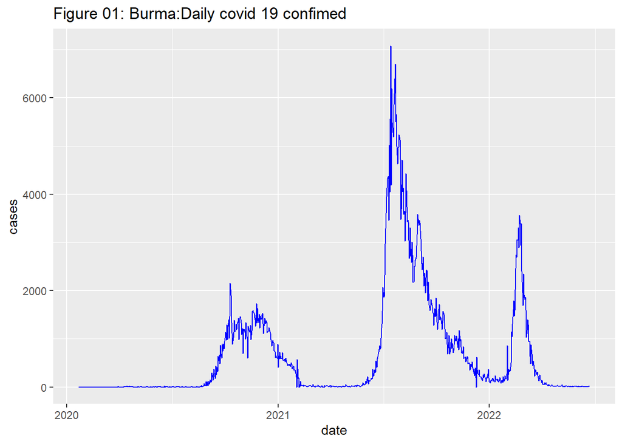

From this figure 01 we can see that the daily confirmed covid cases in Burma reach to a maximum value in the middle of the year 2021 than in the end of 2020 and in the beginning of 2022

#### **2.1.2 Total number of death cases reported from Burma**

```
        date province country     lat   long  type cases uid iso2 iso3 code3
1 2020-01-22     <NA>   Burma 21.9162 95.956 death     0 104   MM  MMR   104
2 2020-01-23     <NA>   Burma 21.9162 95.956 death     0 104   MM  MMR   104
3 2020-01-24     <NA>   Burma 21.9162 95.956 death     0 104   MM  MMR   104
4 2020-01-25     <NA>   Burma 21.9162 95.956 death     0 104   MM  MMR   104
5 2020-01-26     <NA>   Burma 21.9162 95.956 death     0 104   MM  MMR   104
6 2020-01-27     <NA>   Burma 21.9162 95.956 death     0 104   MM  MMR   104
  combined_key population continent_name continent_code
1        Burma   54409794           Asia             AS
2        Burma   54409794           Asia             AS
3        Burma   54409794           Asia             AS
4        Burma   54409794           Asia             AS
5        Burma   54409794           Asia             AS
6        Burma   54409794           Asia             AS
```

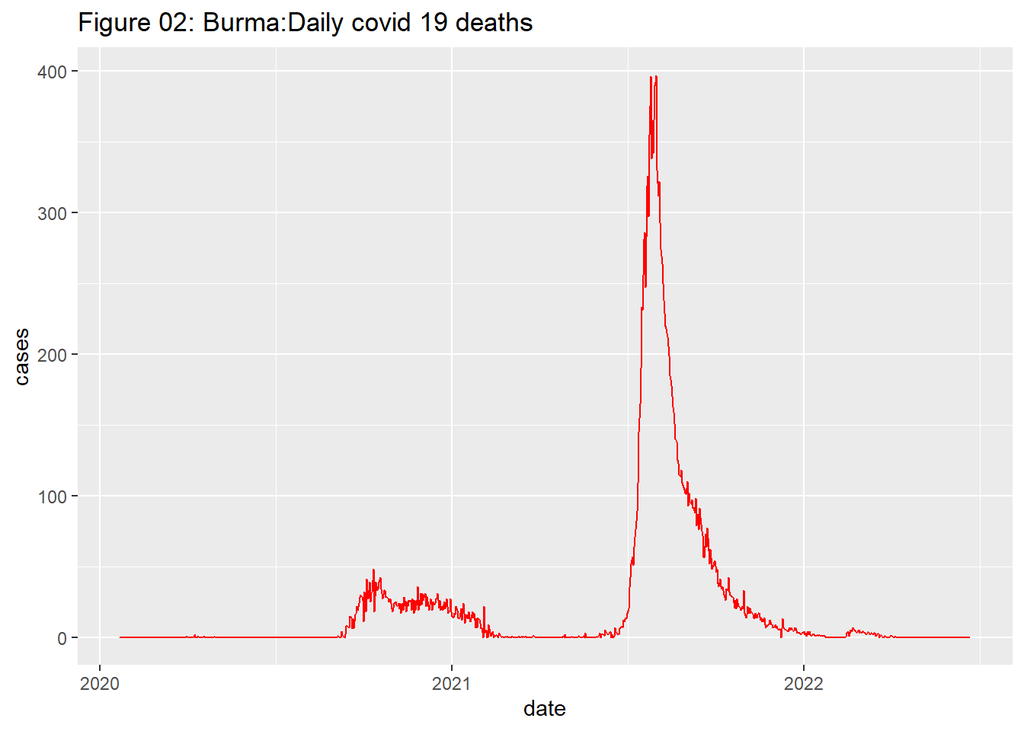

From this figure 02 we can see that the daily confirmed covid deaths have peaked to a maximum about 400 in July of 2021

#### **2.1.3 Total number of recovered cases reported from Burma**

```
        date province country     lat   long     type cases uid iso2 iso3 code3
1 2020-01-22     <NA>   Burma 21.9162 95.956 recovery     0 104   MM  MMR   104
2 2020-01-23     <NA>   Burma 21.9162 95.956 recovery     0 104   MM  MMR   104
3 2020-01-24     <NA>   Burma 21.9162 95.956 recovery     0 104   MM  MMR   104
4 2020-01-25     <NA>   Burma 21.9162 95.956 recovery     0 104   MM  MMR   104
5 2020-01-26     <NA>   Burma 21.9162 95.956 recovery     0 104   MM  MMR   104
6 2020-01-27     <NA>   Burma 21.9162 95.956 recovery     0 104   MM  MMR   104
  combined_key population continent_name continent_code
1        Burma   54409794           Asia             AS
2        Burma   54409794           Asia             AS
3        Burma   54409794           Asia             AS
4        Burma   54409794           Asia             AS
5        Burma   54409794           Asia             AS
6        Burma   54409794           Asia             AS
```

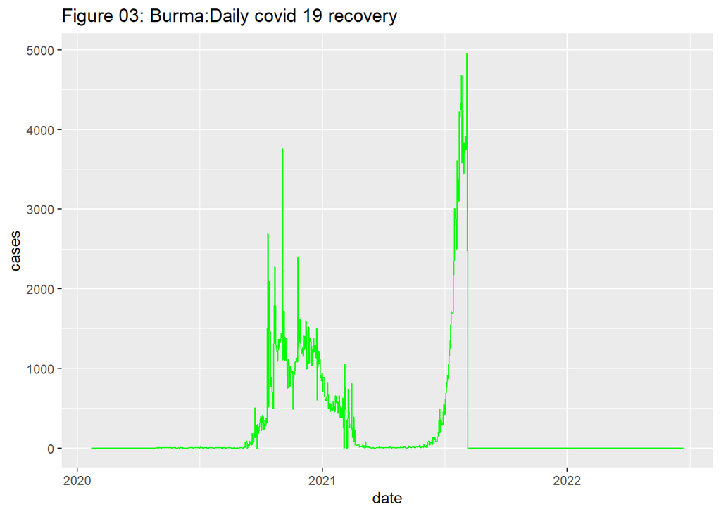

According to the above diagram, at the end of the year 2020 and the beginning of 2021, the number of patients who recovered from the Covid virus is a considerable amount but lesser than the peak value shown in the middle of 2021

#### **2.1.4 Graphically represent all three confirmed,recovered & death cases**

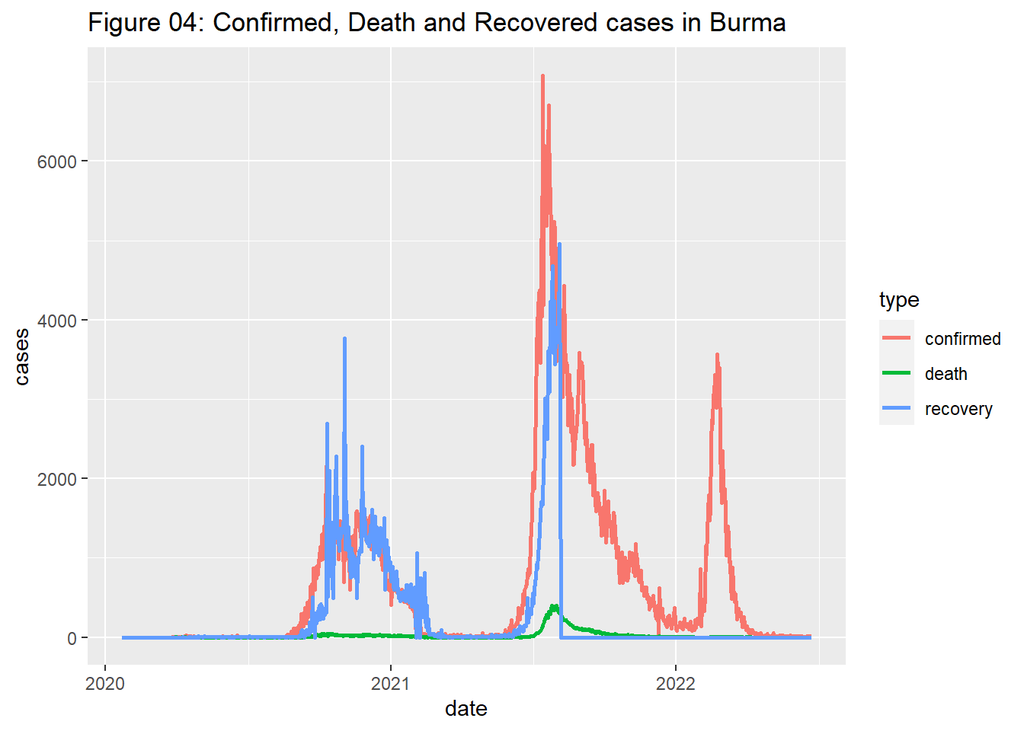

#### **2.1.5 Total number of active cases reported from Burma**

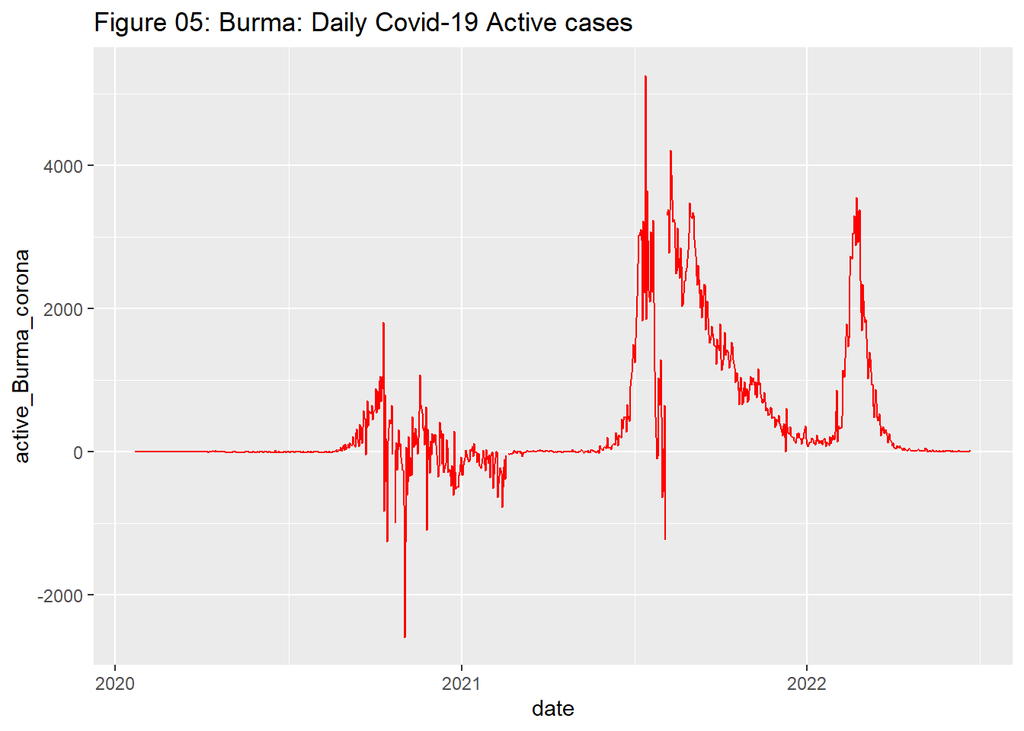

According to Figure 05, we can see that the Covid virus was active in Burma at the end of 2020 and in the middle of 2021.

### **2.2 Comparison with other countries**

#### **2.2.1 Confirmed cases**

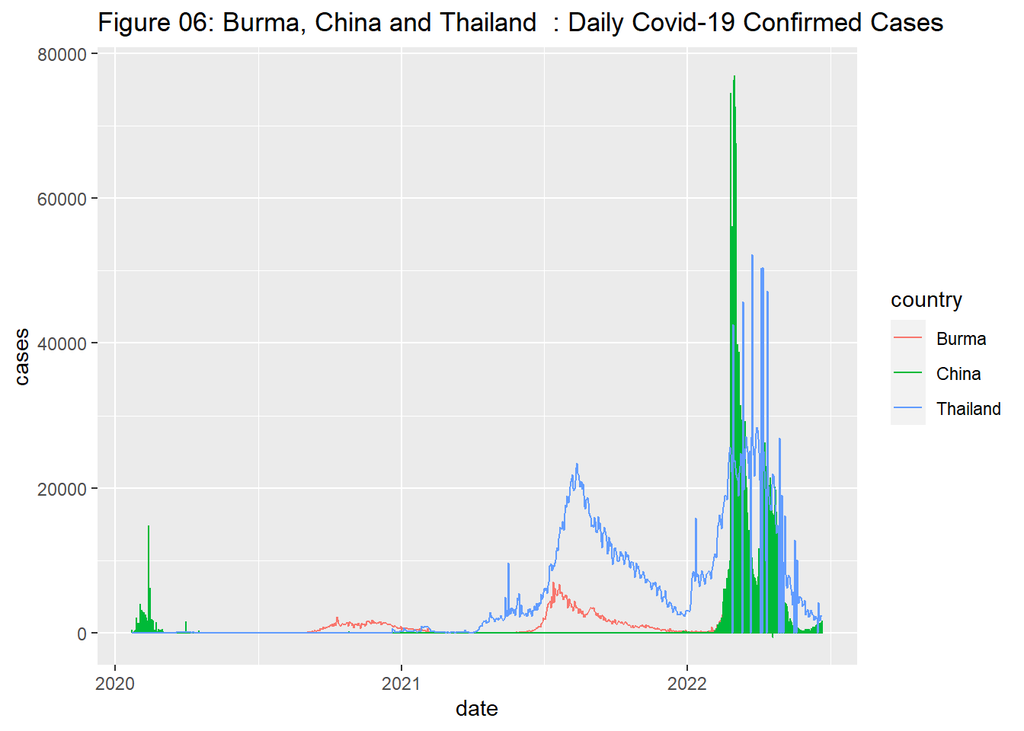

According to the diagram above, the daily number of Covid patients has been compared in the countries of Burma, China and Thailand. In China, the number of patients in 2020 showed a high value, but the number of patients in 2021 is at a minimum. But again after the year 2021, the daily number of Covid patients in China has grown tremendously. Burma and Thailand have seen an increase in the number of cases after 2021.

#### **2.2.2 Recoveries cases**

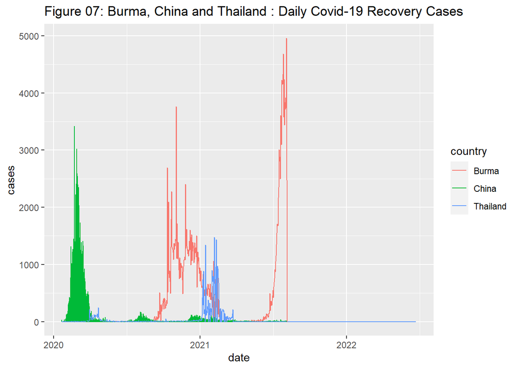

#### **2.2.3 Deaths cases**

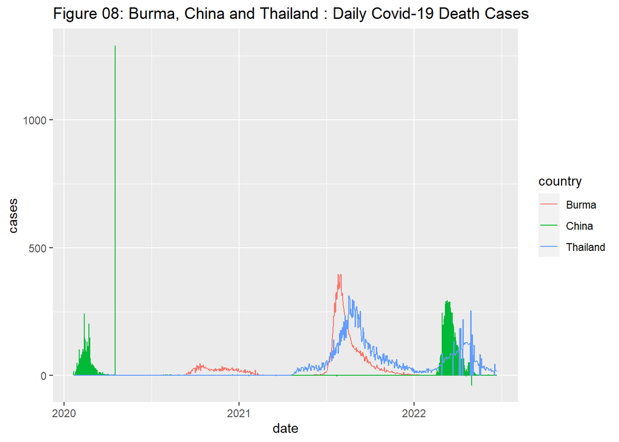

## **3) Conclusions and Discussion**

Considering the number of patients infected with the virus when the Corona virus was active, the number of patients who died during that time is significantly higher than other times.

Also, when the corona virus was active, the number of patients infected with the virus did not recover quickly.

## **4) References**

- https://hellor.netlify.app/slides/onlinehelpdesk
- https://hellor.netlify.app/coronareports/
- https://www.britannica.com/place/Myanmar
- https://en.wikipedia.org/wiki/Myanmar
- https://en.wikipedia.org/wiki/Climate_of_Myanmar
- https://en.wikipedia.org/wiki/COVID-19_pandemic_in_Myanmar
- https://centerforpolicyimpact.org/wp-content/uploads/sites/18/2020/10/Myanmar-National-Response-to-COVID_19.pdf